# Group_22_Final_Project

## CSCN8010 - Foundations of Machine Learning

### Group 22

#### Name: Nasr Alani (Section 1)

#### Student ID: 9039537

#### Name: Paljeet Singh Sambhi (Section 1)

#### Student ID: 8918495

### Use case

Pneumonia is a serious lung disease that can lead to severe health complications if not diagnosed and treated promptly. One effective way to detect pneumonia is through the analysis of chest X-ray images. This dataset provides chest X-ray images of patients, including those diagnosed with pneumonia and those without the disease.

The objective is to develop a machine learning model capable of classifying these X-rays and accurately predicting whether a patient has pneumonia. By leveraging this model, healthcare professionals can streamline the diagnostic process, enabling faster and more reliable detection of the disease, ultimately improving patient outcomes and reducing the burden on radiologists.

##### Downloading dataset with Kaggle Hub

```python
pip install kagglehub
```

```python
import kagglehub

# Download latest version
path = kagglehub.dataset_download("paultimothymooney/chest-xray-pneumonia")

print("Path to dataset files:", path)
```

```
Downloading from https://www.kaggle.com/api/v1/datasets/download/paultimothymooney/chest-xray-pneumonia?dataset_version_number=2...
```

```
Extracting files...
```

```
Path to dataset files: /root/.cache/kagglehub/datasets/paultimothymooney/chest-xray-pneumonia/versions/2
```

##### Moving file to desired path

```python
import shutil

# Define source and destination paths
source = path
destination = "Project_2"

# Move the directory
shutil.move(source, destination)

print("Dataset moved successfully.")
```

```
Dataset moved successfully.
```

```python
import shutil
import os

# Define source and destination directories
source_dir = "Project_2/chest_xray/"
destination_dir = "data_dir"

# Create the destination directory if it doesn't exist
if not os.path.exists(destination_dir):
    os.makedirs(destination_dir)

# Copy 'train' and 'test' folders to the new directory
folders_to_copy = ['train', 'test']
for folder in folders_to_copy:
    source_folder = os.path.join(source_dir, folder)
    destination_folder = os.path.join(destination_dir, folder)
    if os.path.exists(source_folder):
        shutil.copytree(source_folder, destination_folder, dirs_exist_ok=True)
        print(f"Copied {folder} to {destination_dir}.")
    else:
        print(f"Folder {folder} does not exist in the source directory.")

# Remove the folder '2' from the destination directory
folder_to_remove = os.path.join(destination_dir, '2')
if os.path.exists(folder_to_remove):
    shutil.rmtree(folder_to_remove)
    print(f"Removed folder: {folder_to_remove}")
else:
    print(f"Folder '2' does not exist in {destination_dir}.")
```

```
Copied train to data_dir.
Copied test to data_dir.
Folder '2' does not exist in data_dir.
```

#### Checking which set has what count of images

```python
# Function to list all subdirectories and count photos
def count_photos_in_folders(directory):
    folder_counts = {}
    for root, dirs, files in os.walk(directory):
        # Only count files with image extensions
        image_files = [f for f in files if f.lower().endswith(('.png', '.jpg', '.jpeg'))]
        folder_name = os.path.relpath(root, directory)  # Relative folder name
        folder_counts[folder_name] = len(image_files)
    return folder_counts

# Check the directory structure and count photos
photo_counts = count_photos_in_folders(destination_dir)

# Print the structure and photo counts
if photo_counts:
    for folder, count in photo_counts.items():
        print(f"Folder '{folder}': {count} photos")
else:
    print("No photos found in the directory structure.")
```

```
Folder '.': 0 photos
Folder 'test': 0 photos
Folder 'test/PNEUMONIA': 390 photos
Folder 'test/NORMAL': 234 photos
Folder 'train': 0 photos
Folder 'train/PNEUMONIA': 3875 photos
Folder 'train/NORMAL': 1341 photos
```

```python
import os
import random
import shutil

# Define paths
train_dir = os.path.join(destination_dir, 'train')
val_dir = os.path.join(destination_dir, 'val')

# Ensure the validation directory exists
if not os.path.exists(val_dir):
    os.makedirs(val_dir)
```

##### Moving some files to validation as it has very less files

```python
import os
import random
import shutil

# Define paths
train_dir = os.path.join(destination_dir, 'train')
val_dir = os.path.join(destination_dir, 'val')

# Ensure the validation directory exists
if not os.path.exists(val_dir):
    os.makedirs(val_dir)

# Split the train data
for class_name in os.listdir(train_dir):
    class_train_dir = os.path.join(train_dir, class_name)
    class_val_dir = os.path.join(val_dir, class_name)

    # Skip if not a directory
    if not os.path.isdir(class_train_dir):
        continue

    # Create the corresponding class directory in validation
    if not os.path.exists(class_val_dir):
        os.makedirs(class_val_dir)

    # Get all images in the class directory
    images = [img for img in os.listdir(class_train_dir) if img.lower().endswith(('.png', '.jpg', '.jpeg'))]

    # Shuffle and split into 80% train and 20% validation
    random.shuffle(images)
    split_index = int(len(images) * 0.9)
    train_images = images[:split_index]
    val_images = images[split_index:]

    # Move validation images to the validation directory
    for val_image in val_images:
        src_path = os.path.join(class_train_dir, val_image)
        dest_path = os.path.join(class_val_dir, val_image)
        shutil.move(src_path, dest_path)

    # Debugging: Print the process
    print(f"Class '{class_name}' - Moved {len(val_images)} images to validation directory.")

print("Validation directory created and data split completed.")
```

```
Class 'PNEUMONIA' - Moved 388 images to validation directory.
Class 'NORMAL' - Moved 135 images to validation directory.
Validation directory created and data split completed.
```

##### Checking what are the class labels

```python
print(f"Classes in train_dir: {os.listdir(train_dir) if os.path.exists(train_dir) else 'Not found'}")
```

```
Classes in train_dir: ['PNEUMONIA', 'NORMAL']
```

##### Final count of images in each set for each label

```python
# Function to list all subdirectories and count photos
def count_photos_in_folders(directory):
    folder_counts = {}
    for root, dirs, files in os.walk(directory):
        # Only count files with image extensions
        image_files = [f for f in files if f.lower().endswith(('.png', '.jpg', '.jpeg'))]
        folder_name = os.path.relpath(root, directory)  # Relative folder name
        folder_counts[folder_name] = len(image_files)
    return folder_counts

# Check the directory structure and count photos
photo_counts = count_photos_in_folders(destination_dir)

# Print the structure and photo counts
if photo_counts:
    for folder, count in photo_counts.items():
        print(f"Folder '{folder}': {count} photos")
else:
    print("No photos found in the directory structure.")
```

```
Folder '.': 0 photos
Folder 'test': 0 photos
Folder 'test/PNEUMONIA': 390 photos
Folder 'test/NORMAL': 234 photos
Folder 'val': 0 photos
Folder 'val/PNEUMONIA': 388 photos
Folder 'val/NORMAL': 135 photos
Folder 'train': 0 photos
Folder 'train/PNEUMONIA': 3487 photos
Folder 'train/NORMAL': 1206 photos
```

##### EDA

```python
import numpy as np
import pandas as pd
import matplotlib.pyplot as plt
import seaborn as sns
import keras
import tensorflow as tf
from keras.models import Sequential
from keras.layers import Dense, Conv2D , MaxPool2D , Flatten , Dropout , BatchNormalization
from sklearn.model_selection import train_test_split
from sklearn.metrics import classification_report,confusion_matrix
from keras.callbacks import ReduceLROnPlateau
from tensorflow.keras.utils import to_categorical
from tensorflow.keras.utils import image_dataset_from_directory
from tensorflow.keras.utils import array_to_img
import cv2
import os
```

### Loading the Dataset

```python
train = image_dataset_from_directory(
    'data_dir/train',
    image_size=(150, 150),
    batch_size=32)
val = image_dataset_from_directory(
    'data_dir/test',
    image_size=(150, 150),
    batch_size=32)
test = image_dataset_from_directory(
    'data_dir/val',
    image_size=(150, 150),
    batch_size=32)
```

```
Found 4693 files belonging to 2 classes.
Found 624 files belonging to 2 classes.
Found 523 files belonging to 2 classes.
```

##### Checking the shape of image

```python
for images, labels in train.take(1):  # `train.take(1)` loads one batch
    print(images.shape)  # prints the shape of the images in the batch
```

```
(32, 150, 150, 3)
```

##### Image count in each class for each set

```python
# Initialize counters for Pneumonia and Normal images
pneumonia_count = 0
normal_count = 0

# Iterate through the batches in the training dataset
for images, labels in train:
    pneumonia_count += tf.reduce_sum(tf.cast(labels == 0, tf.int32)).numpy()  # Count images with label 0 (Pneumonia)
    normal_count += tf.reduce_sum(tf.cast(labels == 1, tf.int32)).numpy()     # Count images with label 1 (Normal)

print(f"Pneumonia images in train: {pneumonia_count}")
print(f"Normal images in train: {normal_count}")

# Repeat the same for validation and test datasets
val_pneumonia_count = 0
val_normal_count = 0
for images, labels in val:
    val_pneumonia_count += tf.reduce_sum(tf.cast(labels == 0, tf.int32)).numpy()  # Count images with label 0 (Pneumonia)
    val_normal_count += tf.reduce_sum(tf.cast(labels == 1, tf.int32)).numpy()     # Count images with label 1 (Normal)

print(f"Pneumonia images in val: {val_pneumonia_count}")
print(f"Normal images in val: {val_normal_count}")

# For Test Set
test_pneumonia_count = 0
test_normal_count = 0
for images, labels in test:
    test_pneumonia_count += tf.reduce_sum(tf.cast(labels == 0, tf.int32)).numpy()  # Count images with label 0 (Pneumonia)
    test_normal_count += tf.reduce_sum(tf.cast(labels == 1, tf.int32)).numpy()     # Count images with label 1 (Normal)

print(f"Pneumonia images in test: {test_pneumonia_count}")
print(f"Normal images in test: {test_normal_count}")
```

```
Pneumonia images in train: 1206
Normal images in train: 3487
Pneumonia images in val: 234
Normal images in val: 390
Pneumonia images in test: 135
Normal images in test: 388
```

### Data Visualization & Preprocessing

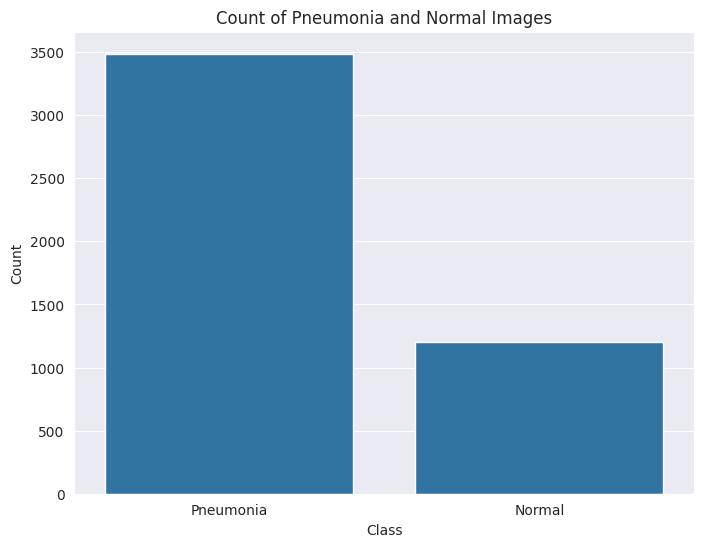

```python
# Initialize an empty list to store the class labels
labels_list = []

# Iterate through the batches in the train dataset
for images, labels in train:
    # Append the class names to the list based on label values
    labels_list.extend(["Normal" if label == 0 else "Pneumonia" for label in labels.numpy()])

# Set Seaborn style
sns.set_style('darkgrid')

# Plot the count of each class using seaborn's countplot
plt.figure(figsize=(8, 6))
sns.countplot(x=labels_list)

# Set plot labels and title
plt.xlabel('Class')
plt.ylabel('Count')
plt.title('Count of Pneumonia and Normal Images')

# Show the plot
plt.show()
```

##### Plotting the image for each label

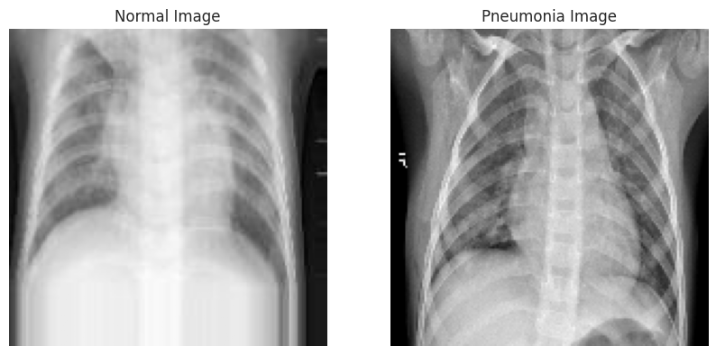

```python
import matplotlib.pyplot as plt
import tensorflow as tf

# Extract one image from each class (Normal and Pneumonia) in the train dataset
normal_image = None
pneumonia_image = None

# Iterate through the dataset
for image, label in train.take(1):
    # Check the label for Normal (0) and Pneumonia (1)
    # Iterate through each label in the batch
    for i in range(len(label)):
        if label.numpy()[i] == 0:  # Normal class
            normal_image = image[i].numpy()  # Get the corresponding image in the batch
            break  # Exit loop once a Normal image is found

    # Iterate through each label in the batch
    for i in range(len(label)):
        if label.numpy()[i] == 1:  # Pneumonia class
            pneumonia_image = image[i].numpy()  # Get the corresponding image in the batch
            break  # Exit loop once a Pneumonia image is found

    if normal_image is not None and pneumonia_image is not None:
        break

# Plot the Normal and Pneumonia images
fig, axes = plt.subplots(1, 2, figsize=(10, 5))

# Plot Normal image
axes[0].imshow(normal_image)
axes[0].set_title('Normal Image')
axes[0].axis('off')  # Hide axes for better visualization

# Plot Pneumonia image
axes[1].imshow(pneumonia_image)
axes[1].set_title('Pneumonia Image')
axes[1].axis('off')  # Hide axes for better visualization

plt.show()
```

##### Checking how many images we have in each label for train set

```python
import tensorflow as tf


# Load images and labels into lists for minority (Normal) and majority (Pneumonia) classes
normal_images = []  # Normal class
pneumonia_images = []  # Pneumonia class
normal_labels = []  # Normal labels
pneumonia_labels = []  # Pneumonia labels

# Unbatch the dataset
for images, labels in train.unbatch():
    if labels.numpy() == 0:  # Normal class
        normal_images.append(images.numpy())
        normal_labels.append(labels.numpy())
    elif labels.numpy() == 1:  # Pneumonia class
        pneumonia_images.append(images.numpy())
        pneumonia_labels.append(labels.numpy())

# Convert to NumPy arrays
normal_images = np.array(normal_images)
pneumonia_images = np.array(pneumonia_images)

# Print the shape of the NumPy arrays
print(f"Normal images: {normal_images.shape}")
print(f"Pneumonia images: {pneumonia_images.shape}")
```

```
Normal images: (1206, 150, 150, 3)
Pneumonia images: (3487, 150, 150, 3)
```

##### Handling Class Bias using oversampling

```python
normal_dir = "data_dir/train/NORMAL"  # Path to NORMAL class folder
if not os.path.exists(normal_dir):
    os.makedirs(normal_dir)

# Augmentations for the NORMAL class (minority class)
datagen = ImageDataGenerator(
    #rotation_range=20,
    width_shift_range=0.2,
    height_shift_range=0.2,
    shear_range=0.2,
    zoom_range=0.2,
    horizontal_flip=True,
    fill_mode="nearest"
)

# Load the dataset into separate lists for augmentation
normal_images = []
for images, labels in train.unbatch():
    if labels.numpy() == 1:  # Normal class
        normal_images.append(images.numpy())

normal_images = np.array(normal_images)

# Number of augmented images to generate (based on desired balance)
n_augmentations = 2281
# Example: Generate 3000 new images

# Generate and save augmented images
augmented_count = 0
for image in datagen.flow(normal_images, batch_size=1, save_to_dir=normal_dir, save_prefix="aug_", save_format="jpeg"):
    augmented_count += 1
    if augmented_count >= n_augmentations:
        break

print(f"{augmented_count} augmented images saved to {normal_dir}.")
```

```
2281 augmented images saved to data_dir/train/NORMAL.
```

##### Loading the updated dataset

```python
train = image_dataset_from_directory(
    'data_dir/train',
    image_size=(150, 150),
    batch_size=32)
val = image_dataset_from_directory(
    'data_dir/test',
    image_size=(150, 150),
    batch_size=32)
test = image_dataset_from_directory(
    'data_dir/val',
    image_size=(150, 150),
    batch_size=32)
```

```
Found 6974 files belonging to 2 classes.
Found 624 files belonging to 2 classes.
Found 523 files belonging to 2 classes.
```

##### Plotting again to see class distribution

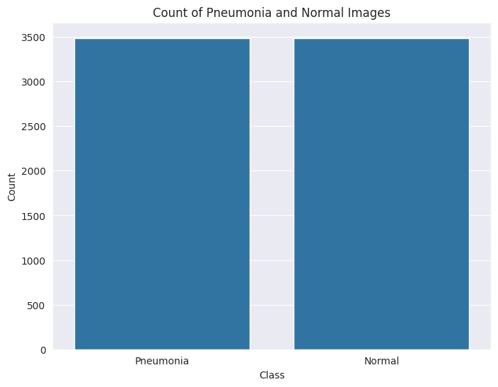

```python
# Initialize an empty list to store the class labels
labels_list = []

# Iterate through the batches in the train dataset
for images, labels in train:
    # Append the class names to the list based on label values
    labels_list.extend(["Normal" if label == 0 else "Pneumonia" for label in labels.numpy()])

# Set Seaborn style
sns.set_style('darkgrid')

# Plot the count of each class using seaborn's countplot
plt.figure(figsize=(8, 6))
sns.countplot(x=labels_list)

# Set plot labels and title
plt.xlabel('Class')
plt.ylabel('Count')
plt.title('Count of Pneumonia and Normal Images')

# Show the plot
plt.show()
```

##### Normalising to make training process faster

```python
def normalize(image, label):
  # Normalize pixel values to the range [0, 1]
  image = tf.cast(image, tf.float32) / 255.0
  return image, label

# Apply normalization to the dataset
train = train.map(normalize)
val = val.map(normalize)
test = test.map(normalize)
```

```python
import tensorflow as tf
from tensorflow.keras.applications import VGG16
from tensorflow.keras.layers import Dense, Flatten, Dropout, GlobalAveragePooling2D
from tensorflow.keras.models import Model
from tensorflow.keras.preprocessing.image import ImageDataGenerator
from tensorflow.keras import Sequential
```

##### Loading the base Vgg16 model and adding output layer

```python
# Load VGG16 without the top layer
vgg16_base = VGG16(weights='imagenet', include_top=False, input_shape=(150, 150, 3))

# Freeze the convolutional base
vgg16_base.trainable = False

# Build a new model with the pre-trained base
model = Sequential([
    vgg16_base,
    Flatten(),
    Dense(256, activation='relu'),
    Dense(1, activation='sigmoid')  # For binary classification
])
```

```python
vgg16_base.summary()
```

```
Model: "vgg16"
```

```
┏━━━━━━━━━━━━━━━━━━━━━━━━━━━━━━━━━━━━━━┳━━━━━━━━━━━━━━━━━━━━━━━━━━━━━┳━━━━━━━━━━━━━━━━━┓
┃ Layer (type)                         ┃ Output Shape                ┃         Param # ┃
┡━━━━━━━━━━━━━━━━━━━━━━━━━━━━━━━━━━━━━━╇━━━━━━━━━━━━━━━━━━━━━━━━━━━━━╇━━━━━━━━━━━━━━━━━┩
│ input_layer (InputLayer)             │ (None, 150, 150, 3)         │               0 │
├──────────────────────────────────────┼─────────────────────────────┼─────────────────┤
│ block1_conv1 (Conv2D)                │ (None, 150, 150, 64)        │           1,792 │
├──────────────────────────────────────┼─────────────────────────────┼─────────────────┤
│ block1_conv2 (Conv2D)                │ (None, 150, 150, 64)        │          36,928 │
├──────────────────────────────────────┼─────────────────────────────┼─────────────────┤
│ block1_pool (MaxPooling2D)           │ (None, 75, 75, 64)          │               0 │
├──────────────────────────────────────┼─────────────────────────────┼─────────────────┤
│ block2_conv1 (Conv2D)                │ (None, 75, 75, 128)         │          73,856 │
├──────────────────────────────────────┼─────────────────────────────┼─────────────────┤
│ block2_conv2 (Conv2D)                │ (None, 75, 75, 128)         │         147,584 │
├──────────────────────────────────────┼─────────────────────────────┼─────────────────┤
│ block2_pool (MaxPooling2D)           │ (None, 37, 37, 128)         │               0 │
├──────────────────────────────────────┼─────────────────────────────┼─────────────────┤
│ block3_conv1 (Conv2D)                │ (None, 37, 37, 256)         │         295,168 │
├──────────────────────────────────────┼─────────────────────────────┼─────────────────┤
│ block3_conv2 (Conv2D)                │ (None, 37, 37, 256)         │         590,080 │
├──────────────────────────────────────┼─────────────────────────────┼─────────────────┤
│ block3_conv3 (Conv2D)                │ (None, 37, 37, 256)         │         590,080 │
├──────────────────────────────────────┼─────────────────────────────┼─────────────────┤
│ block3_pool (MaxPooling2D)           │ (None, 18, 18, 256)         │               0 │
├──────────────────────────────────────┼─────────────────────────────┼─────────────────┤
│ block4_conv1 (Conv2D)                │ (None, 18, 18, 512)         │       1,180,160 │
├──────────────────────────────────────┼─────────────────────────────┼─────────────────┤
│ block4_conv2 (Conv2D)                │ (None, 18, 18, 512)         │       2,359,808 │
├──────────────────────────────────────┼─────────────────────────────┼─────────────────┤
│ block4_conv3 (Conv2D)                │ (None, 18, 18, 512)         │       2,359,808 │
├──────────────────────────────────────┼─────────────────────────────┼─────────────────┤
│ block4_pool (MaxPooling2D)           │ (None, 9, 9, 512)           │               0 │
├──────────────────────────────────────┼─────────────────────────────┼─────────────────┤
│ block5_conv1 (Conv2D)                │ (None, 9, 9, 512)           │       2,359,808 │
├──────────────────────────────────────┼─────────────────────────────┼─────────────────┤
│ block5_conv2 (Conv2D)                │ (None, 9, 9, 512)           │       2,359,808 │
├──────────────────────────────────────┼─────────────────────────────┼─────────────────┤
│ block5_conv3 (Conv2D)                │ (None, 9, 9, 512)           │       2,359,808 │
├──────────────────────────────────────┼─────────────────────────────┼─────────────────┤
│ block5_pool (MaxPooling2D)           │ (None, 4, 4, 512)           │               0 │
└──────────────────────────────────────┴─────────────────────────────┴─────────────────┘
```

```
 Total params: 14,714,688 (56.13 MB)
```

```
 Trainable params: 0 (0.00 B)
```

```
 Non-trainable params: 14,714,688 (56.13 MB)
```

##### Running the fit and saving the best model

```python
model.compile(loss="binary_crossentropy",
              optimizer="adam",
              metrics=["accuracy"])

callbacks = [
    keras.callbacks.ModelCheckpoint(
        filepath="vgg16_base.keras",
        save_best_only=True,
        monitor="val_loss")
]
history = model.fit(
    train,
    epochs=20,
    validation_data=val,
    callbacks=callbacks)
```

```
218/218 ━━━━━━━━━━━━━━━━━━━━ 13s 42ms/step - accuracy: 0.7871 - loss: 0.5317 - val_accuracy: 0.8413 - val_loss: 0.3884
218/218 ━━━━━━━━━━━━━━━━━━━━ 5s 24ms/step - accuracy: 0.9422 - loss: 0.1410 - val_accuracy: 0.7740 - val_loss: 0.5808
218/218 ━━━━━━━━━━━━━━━━━━━━ 6s 27ms/step - accuracy: 0.9644 - loss: 0.0943 - val_accuracy: 0.8510 - val_loss: 0.3796
218/218 ━━━━━━━━━━━━━━━━━━━━ 5s 24ms/step - accuracy: 0.9683 - loss: 0.0809 - val_accuracy: 0.8429 - val_loss: 0.4509
218/218 ━━━━━━━━━━━━━━━━━━━━ 5s 24ms/step - accuracy: 0.9713 - loss: 0.0705 - val_accuracy: 0.8077 - val_loss: 0.6365
218/218 ━━━━━━━━━━━━━━━━━━━━ 5s 25ms/step - accuracy: 0.9784 - loss: 0.0622 - val_accuracy: 0.8093 - val_loss: 0.6763
218/218 ━━━━━━━━━━━━━━━━━━━━ 5s 24ms/step - accuracy: 0.9841 - loss: 0.0497 - val_accuracy: 0.8125 - val_loss: 0.7037
218/218 ━━━━━━━━━━━━━━━━━━━━ 6s 25ms/step - accuracy: 0.9837 - loss: 0.0434 - val_accuracy: 0.7692 - val_loss: 1.0465
218/218 ━━━━━━━━━━━━━━━━━━━━ 5s 24ms/step - accuracy: 0.9798 - loss: 0.0522 - val_accuracy: 0.7724 - val_loss: 1.0562
218/218 ━━━━━━━━━━━━━━━━━━━━ 5s 24ms/step - accuracy: 0.9891 - loss: 0.0313 - val_accuracy: 0.7965 - val_loss: 0.9377
218/218 ━━━━━━━━━━━━━━━━━━━━ 6s 25ms/step - accuracy: 0.9886 - loss: 0.0309 - val_accuracy: 0.8173 - val_loss: 0.7503
218/218 ━━━━━━━━━━━━━━━━━━━━ 5s 24ms/step - accuracy: 0.9955 - loss: 0.0175 - val_accuracy: 0.8109 - val_loss: 1.0244
218/218 ━━━━━━━━━━━━━━━━━━━━ 5s 24ms/step - accuracy: 0.9892 - loss: 0.0277 - val_accuracy: 0.7660 - val_loss: 1.3558
218/218 ━━━━━━━━━━━━━━━━━━━━ 5s 25ms/step - accuracy: 0.9646 - loss: 0.0919 - val_accuracy: 0.8333 - val_loss: 0.5749
218/218 ━━━━━━━━━━━━━━━━━━━━ 6s 25ms/step - accuracy: 0.9936 - loss: 0.0256 - val_accuracy: 0.7917 - val_loss: 0.9342
218/218 ━━━━━━━━━━━━━━━━━━━━ 5s 25ms/step - accuracy: 0.9907 - loss: 0.0260 - val_accuracy: 0.7804 - val_loss: 1.0677
218/218 ━━━━━━━━━━━━━━━━━━━━ 5s 24ms/step - accuracy: 0.9965 - loss: 0.0162 - val_accuracy: 0.7901 - val_loss: 1.0663
218/218 ━━━━━━━━━━━━━━━━━━━━ 5s 24ms/step - accuracy: 0.9960 - loss: 0.0144 - val_accuracy: 0.7436 - val_loss: 1.5632
218/218 ━━━━━━━━━━━━━━━━━━━━ 6s 25ms/step - accuracy: 0.9921 - loss: 0.0237 - val_accuracy: 0.7949 - val_loss: 1.1434
218/218 ━━━━━━━━━━━━━━━━━━━━ 5s 24ms/step - accuracy: 0.9997 - loss: 0.0070 - val_accuracy: 0.8045 - val_loss: 1.0254
```

##### Checking model performance on test set

```python
test_loss, test_accuracy = model.evaluate(test)
print(f"Test Loss: {test_loss}")
print(f"Test Accuracy: {test_accuracy}")
```

```
17/17 ━━━━━━━━━━━━━━━━━━━━ 2s 98ms/step - accuracy: 0.9668 - loss: 0.1100
Test Loss: 0.11918268352746964
Test Accuracy: 0.961759090423584
```

##### Plotting the Accuracy and loss for both training and validation set to check where model started overfitting

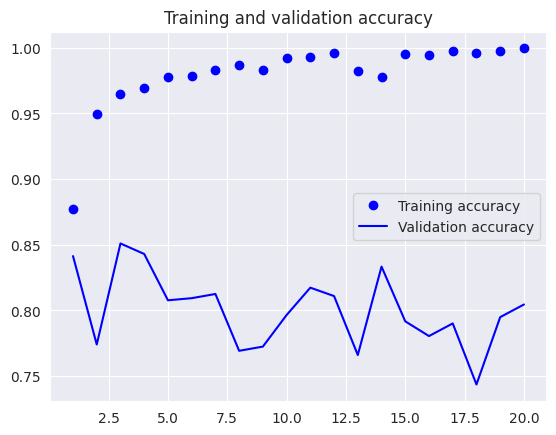

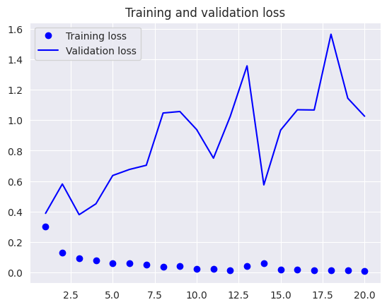

```python
acc = history.history["accuracy"]
val_acc = history.history["val_accuracy"]
loss = history.history["loss"]
val_loss = history.history["val_loss"]
epochs = range(1, len(acc) + 1)
plt.plot(epochs, acc, "bo", label="Training accuracy")
plt.plot(epochs, val_acc, "b", label="Validation accuracy")
plt.title("Training and validation accuracy")
plt.legend()
plt.figure()
plt.plot(epochs, loss, "bo", label="Training loss")
plt.plot(epochs, val_loss, "b", label="Validation loss")
plt.title("Training and validation loss")
plt.legend()
plt.show()
```

##### Testing the saved model on test set

```python
test_model = keras.models.load_model("vgg16_base.keras")
test_loss, test_acc = test_model.evaluate(test)
print(f"Test accuracy: {test_acc:.3f}")
```

```
17/17 ━━━━━━━━━━━━━━━━━━━━ 2s 25ms/step - accuracy: 0.9151 - loss: 0.1934
Test accuracy: 0.910
```

##### Now we will train on VGG19 model

```python
# Load VGG19 without the top layer
vgg19_base = VGG19(weights='imagenet', include_top=False, input_shape=(150, 150, 3))

# Freeze the convolutional base
vgg19_base.trainable = False

# Build a new model with the pre-trained base
model_VGG19 = Sequential([
    vgg19_base,
    Flatten(),
    Dense(256, activation='relu'),
    Dense(1, activation='sigmoid')  # For binary classification
])

# Print the model summary to verify
model_VGG19.summary()
```

```
Downloading data from https://storage.googleapis.com/tensorflow/keras-applications/vgg19/vgg19_weights_tf_dim_ordering_tf_kernels_notop.h5
80134624/80134624 ━━━━━━━━━━━━━━━━━━━━ 4s 0us/step
```

```
Model: "sequential_1"
```

```
┏━━━━━━━━━━━━━━━━━━━━━━━━━━━━━━━━━━━━━━┳━━━━━━━━━━━━━━━━━━━━━━━━━━━━━┳━━━━━━━━━━━━━━━━━┓
┃ Layer (type)                         ┃ Output Shape                ┃         Param # ┃
┡━━━━━━━━━━━━━━━━━━━━━━━━━━━━━━━━━━━━━━╇━━━━━━━━━━━━━━━━━━━━━━━━━━━━━╇━━━━━━━━━━━━━━━━━┩
│ vgg19 (Functional)                   │ (None, 4, 4, 512)           │      20,024,384 │
├──────────────────────────────────────┼─────────────────────────────┼─────────────────┤
│ flatten_1 (Flatten)                  │ (None, 8192)                │               0 │
├──────────────────────────────────────┼─────────────────────────────┼─────────────────┤
│ dense_2 (Dense)                      │ (None, 256)                 │       2,097,408 │
├──────────────────────────────────────┼─────────────────────────────┼─────────────────┤
│ dense_3 (Dense)                      │ (None, 1)                   │             257 │
└──────────────────────────────────────┴─────────────────────────────┴─────────────────┘
```

```
 Total params: 22,122,049 (84.39 MB)
```

```
 Trainable params: 2,097,665 (8.00 MB)
```

```
 Non-trainable params: 20,024,384 (76.39 MB)
```

```python
model_VGG19.compile(loss="binary_crossentropy",
              optimizer="adam",
              metrics=["accuracy"])

callbacks = [
    keras.callbacks.ModelCheckpoint(
        filepath="vgg19_base.keras",
        save_best_only=True,
        monitor="val_loss")
]
history = model_VGG19.fit(
    train,
    epochs=20,
    validation_data=val,
    callbacks=callbacks)
```

```
218/218 ━━━━━━━━━━━━━━━━━━━━ 10s 34ms/step - accuracy: 0.7723 - loss: 0.6461 - val_accuracy: 0.7676 - val_loss: 0.5605
218/218 ━━━━━━━━━━━━━━━━━━━━ 6s 25ms/step - accuracy: 0.9371 - loss: 0.1641 - val_accuracy: 0.7340 - val_loss: 0.7435
218/218 ━━━━━━━━━━━━━━━━━━━━ 6s 26ms/step - accuracy: 0.9546 - loss: 0.1266 - val_accuracy: 0.7933 - val_loss: 0.5422
218/218 ━━━━━━━━━━━━━━━━━━━━ 6s 26ms/step - accuracy: 0.9552 - loss: 0.1139 - val_accuracy: 0.7724 - val_loss: 0.6614
218/218 ━━━━━━━━━━━━━━━━━━━━ 5s 24ms/step - accuracy: 0.9583 - loss: 0.1082 - val_accuracy: 0.7821 - val_loss: 0.6416
218/218 ━━━━━━━━━━━━━━━━━━━━ 5s 24ms/step - accuracy: 0.9670 - loss: 0.0825 - val_accuracy: 0.7548 - val_loss: 0.8042
218/218 ━━━━━━━━━━━━━━━━━━━━ 5s 25ms/step - accuracy: 0.9772 - loss: 0.0636 - val_accuracy: 0.7869 - val_loss: 0.6790
218/218 ━━━━━━━━━━━━━━━━━━━━ 6s 26ms/step - accuracy: 0.9808 - loss: 0.0532 - val_accuracy: 0.8109 - val_loss: 0.5354
218/218 ━━━━━━━━━━━━━━━━━━━━ 5s 24ms/step - accuracy: 0.9817 - loss: 0.0518 - val_accuracy: 0.7869 - val_loss: 0.6997
218/218 ━━━━━━━━━━━━━━━━━━━━ 5s 25ms/step - accuracy: 0.9872 - loss: 0.0400 - val_accuracy: 0.7548 - val_loss: 1.0549
218/218 ━━━━━━━━━━━━━━━━━━━━ 5s 24ms/step - accuracy: 0.9802 - loss: 0.0543 - val_accuracy: 0.8045 - val_loss: 0.6916
218/218 ━━━━━━━━━━━━━━━━━━━━ 5s 25ms/step - accuracy: 0.9866 - loss: 0.0376 - val_accuracy: 0.7388 - val_loss: 1.3089
218/218 ━━━━━━━━━━━━━━━━━━━━ 5s 24ms/step - accuracy: 0.9764 - loss: 0.0609 - val_accuracy: 0.8045 - val_loss: 0.6637
218/218 ━━━━━━━━━━━━━━━━━━━━ 5s 24ms/step - accuracy: 0.9928 - loss: 0.0261 - val_accuracy: 0.7436 - val_loss: 1.2642
218/218 ━━━━━━━━━━━━━━━━━━━━ 6s 25ms/step - accuracy: 0.9929 - loss: 0.0264 - val_accuracy: 0.7596 - val_loss: 1.1973
218/218 ━━━━━━━━━━━━━━━━━━━━ 5s 24ms/step - accuracy: 0.9895 - loss: 0.0304 - val_accuracy: 0.7484 - val_loss: 1.3578
218/218 ━━━━━━━━━━━━━━━━━━━━ 5s 24ms/step - accuracy: 0.9952 - loss: 0.0175 - val_accuracy: 0.7612 - val_loss: 1.2072
218/218 ━━━━━━━━━━━━━━━━━━━━ 5s 25ms/step - accuracy: 0.9962 - loss: 0.0165 - val_accuracy: 0.7596 - val_loss: 1.2786
218/218 ━━━━━━━━━━━━━━━━━━━━ 5s 24ms/step - accuracy: 0.9963 - loss: 0.0144 - val_accuracy: 0.7756 - val_loss: 1.1255
218/218 ━━━━━━━━━━━━━━━━━━━━ 6s 26ms/step - accuracy: 0.9904 - loss: 0.0250 - val_accuracy: 0.7804 - val_loss: 1.0324
```

##### testing model performance over test set

```python
test_loss, test_accuracy = model_VGG19.evaluate(test)
print(f"Test Loss: {test_loss}")
print(f"Test Accuracy: {test_accuracy}")
```

```
17/17 ━━━━━━━━━━━━━━━━━━━━ 1s 56ms/step - accuracy: 0.9358 - loss: 0.2248
Test Loss: 0.23023806512355804
Test Accuracy: 0.9388145208358765
```

##### Plotting the Accuracy and loss for both training and validation set to check where model started overfitting

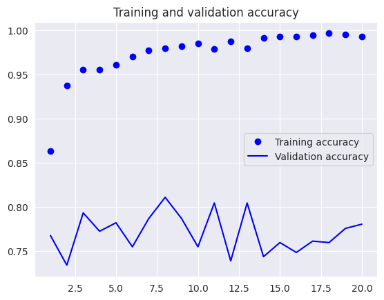

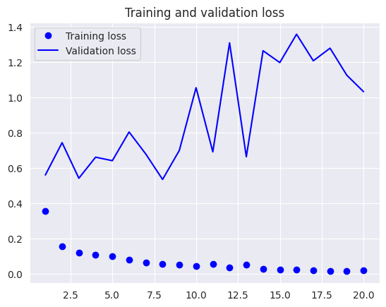

```python
acc = history.history["accuracy"]
val_acc = history.history["val_accuracy"]
loss = history.history["loss"]
val_loss = history.history["val_loss"]
epochs = range(1, len(acc) + 1)
plt.plot(epochs, acc, "bo", label="Training accuracy")
plt.plot(epochs, val_acc, "b", label="Validation accuracy")
plt.title("Training and validation accuracy")
plt.legend()
plt.figure()
plt.plot(epochs, loss, "bo", label="Training loss")
plt.plot(epochs, val_loss, "b", label="Validation loss")
plt.title("Training and validation loss")
plt.legend()
plt.show()
```

By the above two plots we can see that model started to over-fit after epoch 8

```
1/1 ━━━━━━━━━━━━━━━━━━━━ 0s 23ms/step
1/1 ━━━━━━━━━━━━━━━━━━━━ 0s 22ms/step
Normal sample prediction: [[0.00287829]]
Normal sample actual label: 0
Pneumonia sample prediction: [[0.7846119]]
Pneumonia sample actual label: 1
```

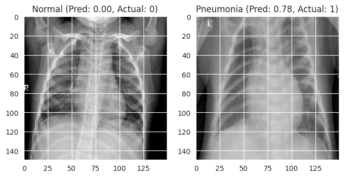

```python
# Sample for each class
normal_sample = None
pneumonia_sample = None

for image_batch, label_batch in test:
  for i in range(len(label_batch)):
    if label_batch[i].numpy() == 0 and normal_sample is None:  # Assuming 0 represents Normal
      normal_sample = image_batch[i].numpy()
      normal_label = label_batch[i].numpy()
    elif label_batch[i].numpy() == 1 and pneumonia_sample is None:  # Assuming 1 represents Pneumonia
      pneumonia_sample = image_batch[i].numpy()
      pneumonia_label = label_batch[i].numpy()
  if normal_sample is not None and pneumonia_sample is not None:
    break

# Make predictions
normal_pred = test_model.predict(np.expand_dims(normal_sample, axis=0))
pneumonia_pred = test_model.predict(np.expand_dims(pneumonia_sample, axis=0))

print(f"Normal sample prediction: {normal_pred}")
print(f"Normal sample actual label: {normal_label}")

print(f"Pneumonia sample prediction: {pneumonia_pred}")
print(f"Pneumonia sample actual label: {pneumonia_label}")


# Display the images (optional)
plt.figure(figsize=(8, 4))

plt.subplot(1, 2, 1)
plt.imshow(normal_sample)
plt.title(f"Normal (Pred: {normal_pred[0][0]:.2f}, Actual: {normal_label})")

plt.subplot(1, 2, 2)
plt.imshow(pneumonia_sample)
plt.title(f"Pneumonia (Pred: {pneumonia_pred[0][0]:.2f}, Actual: {pneumonia_label})")

plt.show()
```